# Your Digest for Thursday, Oct 12, 2023 11:59 PM

## Statins for primary prevention

#2020BSQ-JUL/Q254

- The goal is to lower CVD risk via LDL-C lowering.
- There is no evidence for a particular target.  
  [[#Normal levels for serum lipids]]  
  Indications suggested in UpToDate (slightly different from AHA guidelines- but easier to remember)
- If LDL > 190 and familiar hypercholesterolaemia has been exluded (which must be managed as it's own entity), start high dose (Atorvastatin 40) statin therapy.
- If LDL < 190 mg/dL
  - Decision to start statin is based on 10 year estimated risk
  - **High risk** (>10% risk) -> start statin therapy at moderate dose
  - **Medium risk** (5-10% risk) -> it's complicated. Patient preference is also considered.
  - **Low risk** (*< 5% risk*) -> *No need of statin therapy.*

LDL-c level is measured *SIX TO EIGHT WEEKS* after commencement of therapy.

> [!INFO] when you want to visualize what platelet 'aggregation' means

[figure not shown]

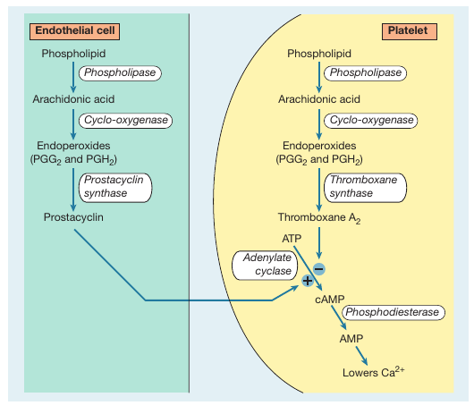

Prostaglandins influence intra platelet calcium via cAMP; Ca2+ is required for the processes which produce platelet aggregation and adhesion.

[figure not shown]

Source

> This is done using fancy formulas such as MDRD formula or the newer CKD-EPI formula which account for age, sex, race etc when producing an eGFR value. [Source](https://reference.medscape.com/calculator/251/egfr-using-ckd-epi-2021-update).

> "The GFR estimate is most commonly derived using 1 of 3 equations: the Cockcroft-Gault,[1] the modification of diet in renal disease (MDRD), or the ([Chronic Kidney Disease]) Epidemiology Collaboration (CKD-EPI).  
> The MDRD and CKD-EPI equations estimate the GFR directly, whereas the Cockcroft-Gault equation estimates creatinine clearance (CrCl).[Source](https://www.medscape.com/viewarticle/762323)  
> In the *elderly*, low muscle mass and *low protein intake* can falsely lower the serum creatinine level.  
> #2020BSQ-JUL/Q25  
> While the natural decline of GFR is factored into the equations above, overall, determining creatinine clearance using the Cockcroft-Gault formula provides more accurate results. [Soure](https://www.ncbi.nlm.nih.gov/pmc/articles/PMC5916085/)

The MDRD and CKD-EPI equations estimate the GFR directly, whereas the Cockcroft-Gault equation estimates [creatinine clearance](https://emedicine.medscape.com/article/2117892-overview) (CrCl)

In the normal brain, there is a balance between dopamine and acetylcholine. In parkinson's disease, the dopamine levels decrease, skewing the balance in favour of acetylcholine.This is why **anticholinergic** drugs can be used to treat the symptoms of Parkinson's disease.

> [!INFO] L+B or L+C  
> levodopa + benserazie = cobeneldopa  
> Levodopa + carbidopa = cocareldopa

> [!INFO] motor complications of treatment
> - End of dose wearing off effect
> - Choreiform movements / dyskinesias
>   - They occur after 2 years of starting levodopa treatment. More with levodopa (compared to dopamine agonists) because levodopa has short half life and concentrations fluctuate.
> - On off phenomena
>   - Also attributed to the short half life of *levodopa*.

#2020BSQ-JUL/Q21

> [!INFO] Dopaminergic side effects of parkinson's treatment
> - Early side effects:
>   - Nausea
>     - Common Side effect of levodopa and dopamine agonists. Can be due to *inadequate* DDC inhibitor. Treat with domperidone but *avoid metoclopramide* which is a dopamine antagonist. Early side effect. Settles with time.
> - Late side effects:
>   - Orthostatic hypotension
>     - A late side effect. Managed by reducing drug doses.
>   - Confusion / hallucinations
>     - Another late side effect. Manage by reducing drug doses.
> - Impulse control disorders (ICDs)
>   - Can occur at any stage of treatment.
>   - Most commonly associated with dopamine agonists.
>   - Severe manifestations include compulsive gambling and hypersexuality
>   - Treatment is to stop DAs and if persistent, possible CBT.

> [!INFO] Withdawal effects
> - Sudden withdrawal can cause *parkinsonism-hyperpyrexia syndrome* - basically, neuroleptic malignant syndrome occuring in the context of antiparkinson drug withdrawal or when switching antiparkinson's agents.
>   - Levodopa or Dopamine agonists should *not* be stopped abruptly.
>   - Abrupt Discontinuation of anticholinergics can cause acute exacerbation of Parkinsonism.
> - Dopamine agonist withdrawal syndrome:
>   - Similar to cocaine or amphetamine withdrawal and include *anxiety, panic attacks, depression*, and *sweating*, nausea, pain, fatigue, dizziness, and drug craving. Only treatment is to restart the dopamine agonist.

| Drug | Mechanism | Clinical context | Side effects |
| --- | --- | --- | --- |
| Levodopa | Dopamine - crosses BBB | *most effective drug*; siginificant improv. initially but effect wears off | Choreiform movements, *wearing off* (duration of action of a dose becomes shorter) and *on/off effects* with prolonged Rx |
| ==Benserazide== (cobeneldopa) |  |  |  |
| ==carbidopa== (cocareldopa) | ==Both== are **dopa decarboxylase inhibitors** | combined with levodopa to reduce side effects |  |
| Dopamine agonists (pramipexole, ropinirole, rotigotine) |  | Less efficacious, less well tolerated BUT **less motor side effects**. Combined with domperidone for antiemesis; used in young*er* patients | Hallucinations, somnolence, compulsive behaviours |
| More Dopamine agonists(Bromocriptine, cabergoline and pergolide) | Dopamine agonists - but they cause lung, pericardial and retroperitoneal fibrosis |  | Lung fibrosis, N/V |
| Selegiline / rasagiline | MAO - inhibit dopamine breakdown |  |  |
| Amantadine | Enhances dopamine release | Modest effect - used in **advanced disease** to improve diskinesia |  |
| Antimuscarinics (orphenadrine) |  | used to reduce tremmor in *younger* patients as confusion can occur in older patients | dry mouth, blurred vision, constipation, nausea, urinary retention, *impaired sweating*, and *tachycardia* |
| Entacapone | Catachol-O-methyltransferase inhibitor (prevents peripheral degradation of levodopa) | Prolongs levodopa action - used to manage on/off phenomena + end of dose 'wearing off'; often combined with levodopa |  |
| Apomorphine | Potent dopamine agonist - short acting | **used as rescue therapy** during an 'off' episode |  |
| istradeffyline | prevent peripheral degration of levodopa | Used as addon treatment to levodopa / carbidopa combination in a patient having 'off episodes' |  |

Can give antipsychotics : quetiepine.

- 📑Thinking is slow and confused but rich in detail. *Ideas of reference and delusions are common.*
- Perception: *visual hallucinations / misinterpretations.* Tactile and auditory hallucinations are less common.
- Disturbances of *memory*: affecting registration, retention and recall.
- Insight: *impaired*
  - 📑so basically any drug
  - 📑Steroids
  - 📑Beta blockers, digoxin, diuretics,
- 📑Neglect syndromes - *parietal* lobe involvement
  - The patient 'neglects' stimuli from the side *contraleteral* to the lesions.

#2020SBR-JUL/Q27

# Overview of types of necrosis

#2020SBR-JUL/Q27

## Pattern of necrosis

- Fibrinoid necrosis is only visible on histology.
- Coagulative necrosis:
  - Characteristic of *infarcts of solid organs*; the insult disrupts digestive proteins as well so that tissue architecture is preserved for days to weeks until phagocytic leukocytes migrate in and digest the debris.
  - Gangrenous necrosis is a type of coagulative necrosis.
- Liquefactive necrosis
  - Occurs at the site of an infection. But hypoxic insult in the CNS also causes liquefactive necrosis.
- Casesous necrosis:
  - Cheese like; characteristic of TB infection. The necrotic mass is friable, like cheese. Cellular architecture is not preserved, unlike coagulative necrosis. Often surrounded by an inflammatory border.
  - This lady knows what is looks like. ;) [Source:Video](https://youtu.be/eYpW9m-AB1A?t=6)
- Fat necrosis:
  - Release of pancreatic lipases into the pancreatic tissue and peritoneal cavity.
  - Lipids are hydrolysed and the resulting fatty acids undergo saponification (to produced soap like substance) by reaction with *calcium.*

## Nuclear changes in necrosis

> Pyknosis:  
> nucleolytic pyknosis which mainly occurs in apoptosis  
> and anucleolytic pyknosis which occurs in necrosis.

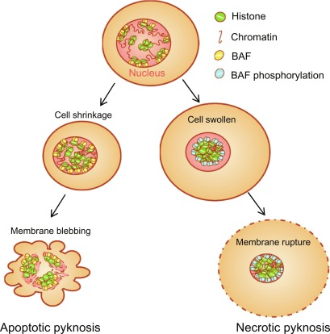

Nuclear morphological alterations

1. Chromatin marginalization :chromatin forms a ring within the periphery of the nucleus. *Seen only in apoptosis.* [Source](https://www.sciencedirect.com/science/article/abs/pii/B9780128239315000244)<- via scienceDirect
2. Pyknosis: nuclear shrinkages; occurs in both apoptosis and necrosis.
3. Karryorhexis - fragmentation of the nucleus
4. Karyolysis - chromatin degradation.
- *Low dose aspirin irreversibly inhibits COX-1*(and also COX-2) -> *inhibits Thromboxane A2 production*. [[Coagulation#^818075|prostacyclin]]
- Platelets cannot make new enzymes (as they're anucleate)
- So platelet activity returns only when new ones are formed in **7-10 days**.
- Toxicity: Decouples oxidative phosphorylation leading to **excessive CO2** production and compensatory **respiratory alkalosis.**. Even *higher doses may cause a high anion gap metabolic acidosis*.
- 5% of patients on aspirin may develop aspirin sensitive asthma; mechanism is not clear. May be COX Inhibition.

> #2020BSQ-JUL/Q24
> - **Low doses** (typically 75 to 81 mg/day) are sufficient to *irreversibly* acetylate serine 530 of cyclooxygenase *(COX)-1*. This effect inhibits platelet generation of thromboxane A2, resulting in an **antithrombotic effect**

## P2Y12 (adenosine) receptor angatonists

#2020BSQ-JUL/Q24

- 📑Clopidogrel (which is a prodrug) and prasugrel irreversibly inhibit the binding of adenosine to P2Y12 receptors
- 📑**Ticagrelor produces non-competitive reversible inhibition.**
- 📑They *inhibit adenosine mediated platelet **aggregation**.*
- 📑Clopidogrel is the *prodrug*. It's activated by the CYP2C19 enzyme system which can be inhibited by **omeprazole!**. Don't co administer the drugs.
  - �Prasugrel is **not used after ischemic stroke / TIA** due to increased bleeding risk.
- **Tirofiban** and eptifibatide are also IIb/IIIa blockers which are given IV to reduce early events in ACS.

## Insulin administration in the elderly

#2020BSQ-JUL/Q254  
This [Source](https://www.medscape.com/viewarticle/705672_3) and other articles in general seem to indicate that basal bolus regimes are too rigorous to follow for elderly people.  
**Morning** basal insulin regimens may be recommended. Usually, for fasting hyperglycaemia, nocturnal basal dose is given.

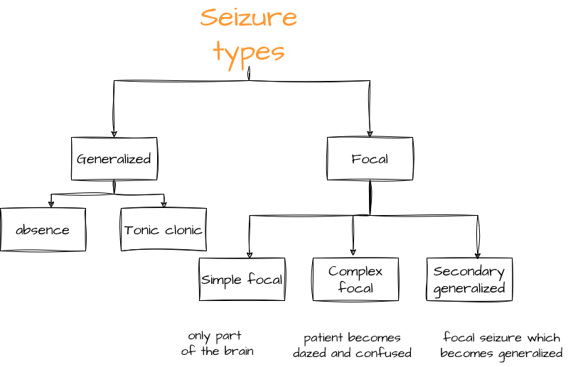

- **Ethosuximide** -> used for absence seizures.
  - Does **not** work for partial seizures.
- **Levetiracetam**: Drug of choice for partial and / or secondary generalized seizures. Non sedating.
- **Lamotrigine** is also a first line drug for *partial* **and** *generalized* epilepsy. Non sedating.  
  [Source](https://www.uptodate.com/contents/overview-of-the-management-of-epilepsy-in-adults?topicRef=312&source=see_link) + Bennet & Brown.
- **Carbamazepine** -> can worsen *absence*, *myoclonic* and *atonic* seizures, and primary generalized seizures.
- **Phenytoin** -> can worsen *absence*, *myoclonic* seizures.
- **Lamotrigine** -> can worsen *myoclonic* seizures

These drugs, (among others) work by blocking sodium channels.  
They show 'use dependence' whereby more frequently depolarizing neurons are affected more.

## Lamotrigine

Is a substrate for inducible hepatic enzymes; dose must be **increased**in **pregnancy**!!

## Benzodiazepiens

are used for acute management of seizure. Not for seizure prophylaxis.  
however, clonazepam is used to achieve rapid control of epilepsy. (eg. When a patient with frequent seizures presents for the first time).

- **Increases GABA levels**.
- **Hair curling** / **thinning** (alopecia)
- **Hepatotoxicity**
- **Very Potent** **teratogen** (more than other AEDs)

# Management of status epilepticus

Rapid summary:

1. Airway, breathing, circulation stabilization
2. First dose of diazepam or lorazepam
3. If not responding, second dose after 5 minutes
4. Repeat a third dose of benzodiazepine.
5. If not responding at 15 minutes, emergency neurology consultation
   1. Start IV **fosphenytoin** 5-10 of PE/kg (PE - phenytoin equivalents)
      1. Forphenytoin is the less cardiotoxic prodrug of phenytoin.
      2. Calculate the required phenytoin dose.
      3. Administer that number of "phenytoin equivalents";

[figure not shown]

      4. [Source](https://www.aliem.com/understanding-phenytoin-equivalents/)
   2. Prepare for ICU transfer
6. If seizure continuing at 30 minutes, prepare for rapid sequence intubation and start midazolam infusion / propofol / **phenobarbital**.
7. Titrate infusion.  
   See UpToDate algorithm for details.